# Dolomite Mineral Farming Calculation

DC

# What is Dolomite

Dolomite is a DeFi protocol that combines a lending platform and DEX. It offers broad token support, capable of listing thousands of assets, including non-standard tokens. Dolomite’s architecture features an immutable core layer and a mutable module layer, enabling capital efficiency through its virtual liquidity system. Users can engage in over-collateralized loans, margin trading, spot trading, and other financial instruments while retaining control over their assets. The protocol aims to become a DeFi hub, allowing users to hedge portfolios, leverage assets, and unlock dormant equity.

# Funding

**Strategic Financing Round (March 2024):**

Amount raised: $900,000

Investors included: Optic Capital, Sandeep Nailwal, DCF GOD…

**Funding Round (May 15, 2023):**

Amount raised: $2.5 million

Investors included:

- Lead: NGC Ventures, Draper Goren Holm
- Coinbase Ventures, 6th Man Ventures, WWVentures, Token Metrics Ventures, RR2 Capital, Slappjakke, Matthew Finestone, David Bleznak, and others.

**Total raised: 3.4 million**

# What is Mineral

Minerals are non-transferrable ERC-20 tokens in Dolomite’s loyalty program, collected weekly based on the volume of qualifying liquidity provided. They hold no value and cannot be traded but enable users to earn XP and compete on a leaderboard, incentivizing engagement and liquidity provision on the platform.

## Airdrop potential

Although Corey and Adam (founders) explicitly said there is no token airdrop, considering the fact that Dolomite is funded by a variety of VCs and having a point system, if there is a token distribution scheme, the emphasis will very likely to be on Mineral.

## Mineral Landscape

Every week:

USDC – 1 Mineral

ETH – 5000 Minerals

WBTC – 75000 Minerals

[figure not shown]

A polynomial regression almost fits this dataset perfectly. By using the same algorithm, we can predict that the total amount of minerals will surpass 3 billion in 12 weeks.

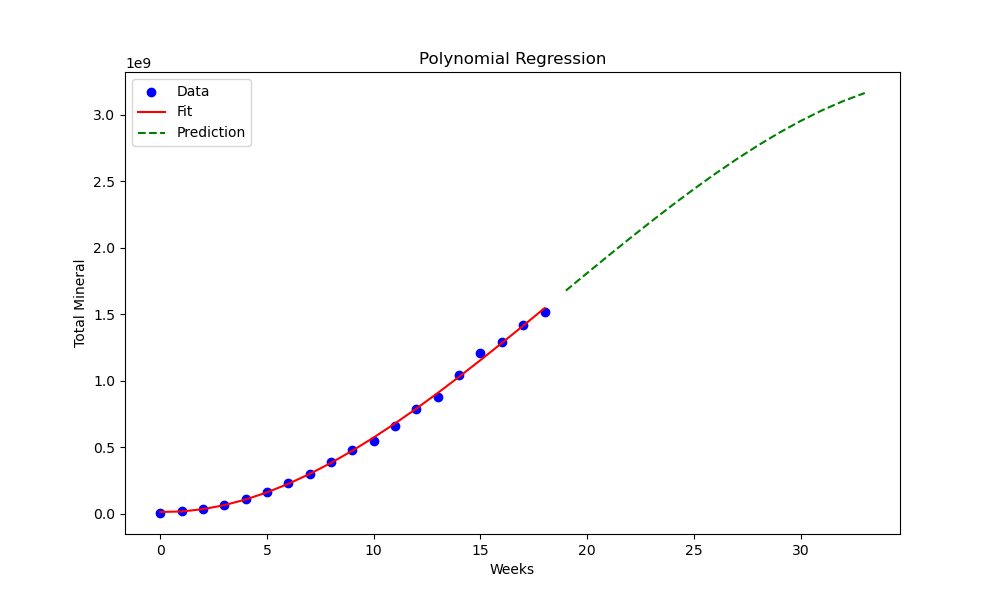

This is an optimistic estimate since it only accounts for claimed Minerals. By calculating how much liquidity was provided on ARB, we calculated how much Minerals should be produced without a multiplier, and the number is relatively steady across these weeks, in contrast to a fluctuating number of claimed Minerals per week.

[figure not shown]

This suggests that not every produced mineral is being claimed, meaning the actual number of Minerals will only be greater than our calculation. In the worst case, every mineral gets a 5X, generating over 160 million Minerals every week. Meaning over 50% of minerals are not claimed. Assuming users on Mantle follow the same behavioral pattern, approximately 200 million Minerals will be generated each week.

# Airdrop calculations

$2.5 million was raised from VCs, along with another $0.9 million from angels. The valuation of Dolomite can easily go over $25 million. Based on airdrops in the past, a proportion of 2.5% - 10% airdrop would be likely.

Here is a picture of projected returns & APR based on our prediction.

I used 10K USDC and 4 ETH as two examples, at the current market price, both at $10K notional value. The blue part is the notional yield and the rose part is the yield converted to APR%.

Note that this is just about vanilla minerals without any looping involved, not to mention the multiplier.

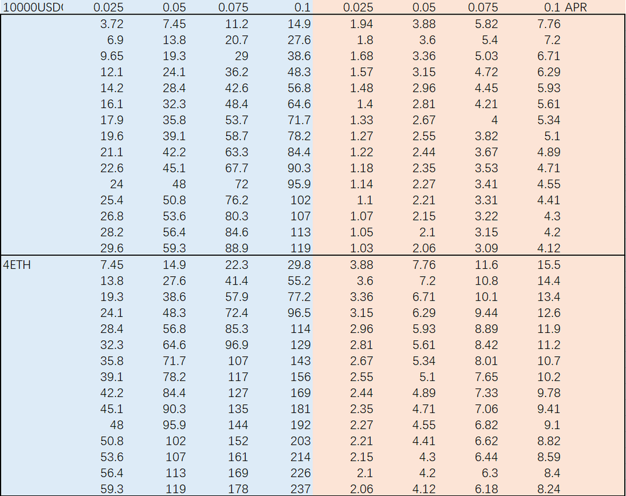

# Farming Strategies

## Looping

For ETH positions, Dolomites offers a variety of LRT/LST for DN strategy. rsETH is currently borrowing at 5.2% APR while ETH is lending 4.4% APR. An LTV of 86.95% allows you to do 7X your initial capital. If you hold assets long enough, there is another 5X multiplier, giving you 35X Mineral in total. In the 5% airdrop situation and TGE happening in 15 weeks, you will get over 144% APR.

Tips: you can borrow more than one assets at the same time to balance the rate fluctuation.

## YT

Dolomite has also collaborated with Pendle to have deposited USDC as a Pendle-wrapped token -dUSDC. 1 YT-dUSDC is currently at 12.8% APY, which costs you $0.007. You can easily do a 140X leverage using it. While the Dolomite lending rate of USDC is at 11% APR, you are getting a good part of your capital back in means of lending rewards.

[figure not shown]

The problem with YTs is that you are not actually getting 1 USDC amount of rewards with 1 YT, although that is the statement on Pendle.

On top of Pendle’s operation fee, it takes another 10% as a reserve. So, you are actually only getting 900 USDC yield with 1000 YTs.

Although you do get a 3X mineral bonus from it. I would still recommend looping instead of buying YTs unless you really hate looping.